# PAC 2 Visualitzacio de dades

Adrià

2025-11-04

```r
# Importem les llibreries necesaries

library(readxl)
library(ggplot2)
library(ggvenn)
library(ggrain)
library(dplyr)
library(lubridate)
library(spiralize)
library(grid)
library(viridis)
```

# Venn Diagram

## Descripció:

Els diagrames de Venn van començar a sorgir l’any 1880, creats per John Venn. S’utilitzaven per ensenyar teoria introductòria, a més d’il·lustrar les relacions entre diferents conjunts, vectors, probabilitats, etc.

Un dels avantatges dels diagrames de Venn és que, si vols veure una correlació entre un nombre reduït d’atributs, és molt fàcil de comprendre i de visualitzar. En canvi, si hi ha més de quatre atributs, ja comença a ser confús i menys comprensible. Per això, es sol recomanar de fer-los amb un màxim de tres atributs.

Alguns exemples de dades que es poden utilitzar serien:

- Preferències de gèneres musicals d’un grup de persones.
- Productes que compren els clients en una botiga.
- Característiques compartides entre animals, com mamífers, que tenen plomes o que poden volar.

```r
vendi_df <- read_excel("GSE75192_counts_RPKMs.xls")

# columnes per teixit
liver_cols <- grep("_liver$", colnames(vendi_df), value = TRUE)
skin_cols <- grep("_skin$", colnames(vendi_df), value = TRUE)
brain_cols <- grep("_brain$", colnames(vendi_df), value = TRUE)

# gen present si expressió > 0 en qualsevol mostra del teixit
liver_genes <- rownames(vendi_df)[apply(vendi_df[, liver_cols], 1, function(x) any(x > 0))]
skin_genes <- rownames(vendi_df)[apply(vendi_df[, skin_cols], 1, function(x) any(x > 0))]
brain_genes <- rownames(vendi_df)[apply(vendi_df[, brain_cols], 1, function(x) any(x > 0))]

venn_list <- list(
  liver = liver_genes,
  skin = skin_genes,
  brain = brain_genes
)

ggvenn(
  venn_list,
  fill_color = c("red", "blue", "purple"),
  stroke_size = 0.5,
  set_name_size = 3
)
```

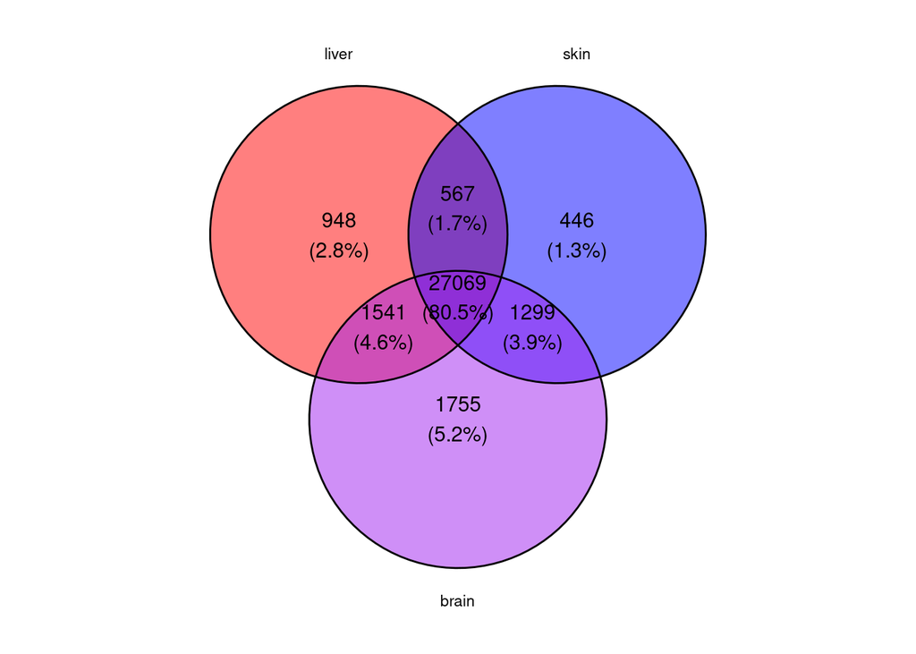

# Rain cloud Plots

## Descripció:

Alguns factors que aporten avantatge respecte a altres tipus de gràfics són la facilitat per detectar outliers i una millor interpretació dels boxplots. Com a desavantatges, requereixen més espai visual i poden resultar més complexos d’entendre en una única ullada.

S’utilitzen amb dades quantitatives contínues i numèriques agrupades en categories. Alguns exemples serien:

- Valors de temps de reacció en dos grups experimentals
- Mesures fisiològiques com la freqüència cardíaca o l’activitat neuronal

Nivells d’un biomarcador abans i després d’un tractament

Àrees d’aplicació habituals:

- Neurociència
- Psicologia i comportament
- Biomedicina i recerca clínica

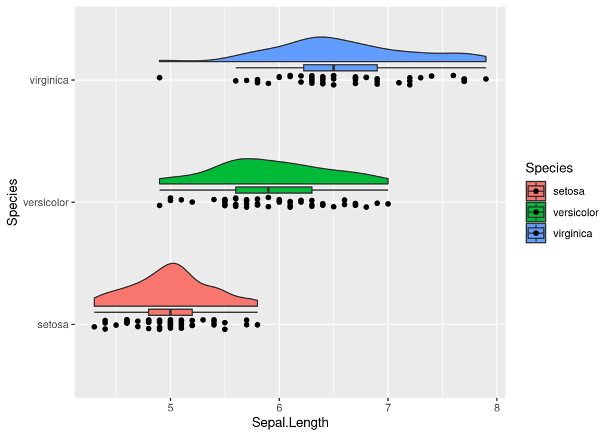

```r
ggplot(iris, aes(Species, Sepal.Length, fill = Species)) +
    geom_rain() +
  coord_flip()
```

# Spiral Plot

## Descripció:

El concepte de spiral plot va començar a sorgir l’any 2000, amb Zuguang Gu com a autor principal. Alguns avantatges destacats són la capacitat de visualitzar sèries temporals llargues de manera compacta i contínua, la facilitat per detectar patrons periòdics com cicles mensuals o anuals, i l’eficiència en l’ús de l’espai visual sense perdre llegibilitat. A més, tenen un fort atractiu visual, útil en contextos de presentació o divulgació.

Com a inconvenients, poden resultar més difícils d’interpretar per a persones no familiaritzades amb aquest format, ja que combinen escales radials i angulars. També requereixen decisions de disseny específiques que poden complicar la comparació entre visualitzacions.

S’utilitzen principalment amb dades quantitatives mesurades al llarg del temps, especialment quan hi ha un component cíclic com mesos o anys, o quan es volen comparar categories al llarg de diferents períodes. No són adequats per a dades sense dimensió temporal clara.

Exemples comuns inclouen:

- Representació de temperatures globals des de 1850 per visualitzar patrons anuals
- Dades de consum energètic amb cada volta representant un any

Àmbits d’aplicació habituals:

- Ciència de dades i recerca en climatologia, economia o salut pública
- Presentacions i articles que busquen un efecte visual notable

```r
df <- read.csv("CLVMNACSCAB1GQES.csv")

df <- df %>%
  mutate(
    date = as.Date(observation_date),
    year = year(date),
    id = row_number(),
    value_norm = scales::rescale(CLVMNACSCAB1GQES) # normalitzar 0 - 1
  )


years <- sort(unique(df$year))

year_colors <- setNames(
  viridis(length(years)),   # paleta en gradient
  years
)

df <- df %>%
  mutate(col = year_colors[as.character(year)])

spiral_initialize(xlim = c(0, max(df$id)))

spiral_track(height = 0.5)

spiral_bars(
  pos = df$id,
  value = df$value_norm,
  gp = gpar(fill = df$col, col = NA)
)

df_year_start <- df %>%
  group_by(year) %>%
  slice(1) %>%
  ungroup()


spiral_axis(
  major_at = df_year_start$id,
  labels = df_year_start$year,
  labels_gp = gpar(cex = 0.6)
)
```

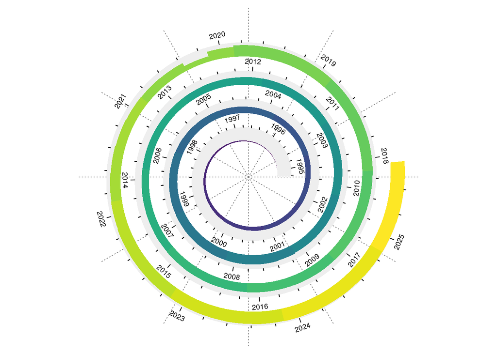